# Medicare: A look at the Largest Single Payer System in the United States

Matthew Farris

December 18, 2016

## Introduction:

Medicare Prospective Payment System, is a complex and diverse system of payments that have substantially influenced the inpatient hospital systems throughout the country. In brief, our medicare program is governed by a system of rules and regulations that hospitals must follow in order to be adequately paid. The origins of Medicare are long-standing, but as one of the only “Federally” mandated insurance program, Medicare is our one link to insight regarding our healthcare in this country. Most private insurance companies use Medicare guidelines as precedent for establishing their own contracts and payments. Unfortunately, due to the contractual nature of these private organizations, the public, as a whole is not privy to the reimbursement of these insurance companies. However, Medicare has released all of its available data encompassing payments for roughly 66% of hospitals. As Medicare, is our standard for payment, we will use these payments to understand and propose new standards for hospital care. Healthcare in this country is a complex, convoluted, and individualistic payment system that varies dramatically from hospital to hospital. Our main goal with this project is to ask the questions, How is this system working? What problems does it have?

## Proposal

In our proposal we divided up the project into 3 categories:

**Analysis of Poverty Rates vs. Payments**

Our first proposal was to do a detailed analysis of poverty rates vs. payments however, as visiualized in the below graphic:

```r
Map
```

[output not shown]

```r
library(choroplethr)
```

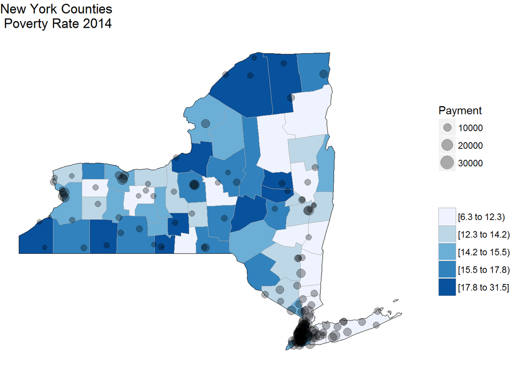

```r
library(ggplot2)
choro_pov = county_choropleth(reg_pov, state_zoom="new york", num_colors=5) +
  ggtitle("New York Counties\n Poverty Rate 2014") +
  geom_point(aes(Long, Lat, size = Payment, group = NULL),
             data=ny_hosp_info,
             alpha = I(0.3))+
  coord_map()
choro_pov
```

As you can see from the above graphic, the hospitals are not evenly sparsed across the counties, and in fact you can see that even outside New York City, the hospital tend to bunch along easily accessible routes and cities. This makes any comparision with poverty rates in the surround arreas difficult, so for our purposes here we shifted away from socioeconomic indicators and moved towards medicare’s own standards.

**Payment vs. Indicators** The second part of project, the focus turned to indicator data. Here the analysis turned to basic linear regression modelling. The goal here was to provide a break down of the data itself, to better understand our collected data, and in the end provide us with a comprehensive data set to analyse.

**Modelling**

The last part to our proposal was building of a model to better understand Medicare and Insurance payment systems. Throught the data analysis provided regarding Readmission vs. Payment data, our focus was narrowed to a specific area of focus for Medicare, that of readmissions, and we could then produce a intricate deciscion tree model that we could test with simulations.

## Readmission Rates

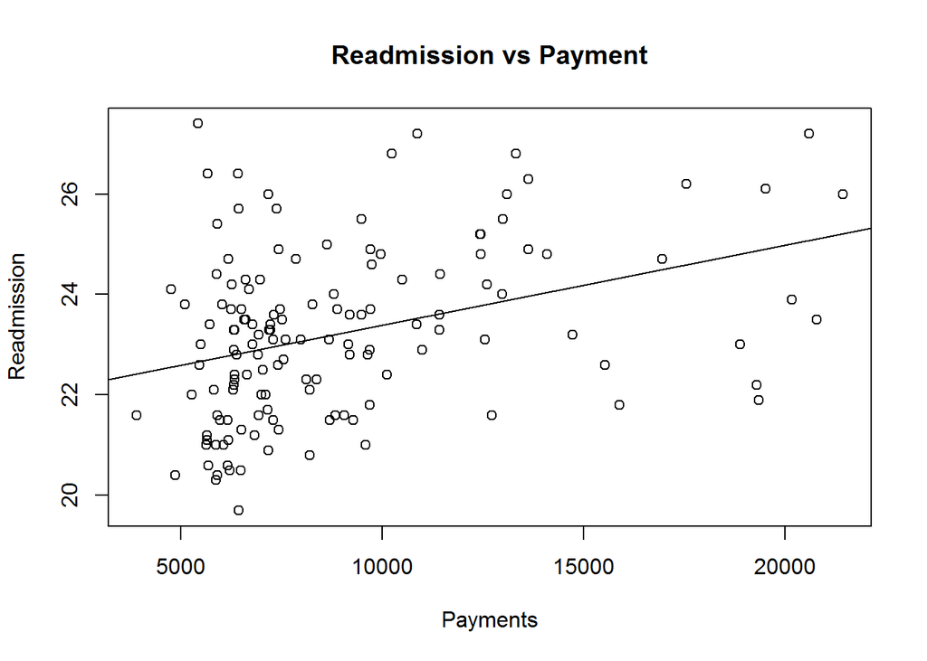

```r
fit<-lm(ny_hf$READM ~ ny_hf$Average.Medicare.Payments)

plot(ny_hf$Average.Medicare.Payments,ny_hf$READM,
     main = "Readmission vs Payment",
     xlab = "Payments",
     ylab = "Readmission")
abline(fit)
```

## Modelling

### Observation

Observation is a separate status from ED and Inpatient. For the most part, observation acts as an intermediate level of care, an “in between.” Observation is meant for short-stay hospital visits, those that are just too long for a patient to remain in the ED, but too short to be fully admitted into the hospital. Though the care that is provided is expected to be the same as an inpatient stay, the payment is vastly different.

Though the exact payment for observation level of care can very tremendously, and all depends on careful billing and documentation guidelines. With the new OPPS Prospective billing, medicare now created a starting packaged rate of $2,200 dollars. This does not reflect the entirety of payments (ie. ED services, which can be billed separately unlike in inpatient were these services packaged together). For simplicity sake, we are going to assume that observation pays roughly $3000, which is hypothetically correct (ED visits usually cost around $800-$1000)

Why do you ask is observation important? Because now hospitals have a decision to make, whether or not to admit as an inpatient, and risk the readmission, or observe the patient in observation, and forgo any penalties. Below we created a generic decision tree, that highlights a hospitals choices:

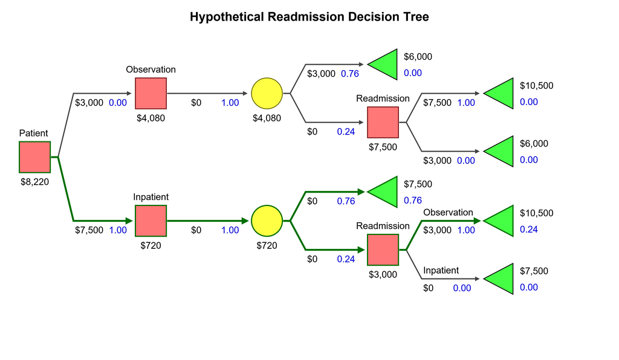

Hospital Readmission Hypothetical

Heart Failure:

```r
#hf_ream<- aggregate(ny_hf$Average.Medicare.Payments, mean)
```

## Decision Tree Modelling:

```r
model_hosp <- function(dat_frame,obs,obs_prop,readm_prop){
  payments <- c()
  readmission <- c()

  for (i in 1:length(dat_frame[,"Average.Medicare.Payments"])){
    pay <- 0
    readm <- 0
    payment <-0
    readm_num <-0
    for (j in 1:100){
      obs_1 <-sample(c(TRUE,FALSE),1, prob = c(obs_prop,1-obs_prop))
      readm_1 <-sample(c(TRUE,FALSE),1, prob = c(readm_prop,1-readm_prop))
      obs_2 <-sample(c(TRUE,FALSE),1, prob = c(obs_prop,1-obs_prop))
      readm_num <- 0
      if (obs_1 == TRUE){
        payment <-obs
        if((readm_1 == TRUE) & (obs_2 ==TRUE)){
          payment<- payment + obs
          readm_num <- 1
        }else if ((readm_1 == TRUE) & (obs_2 ==FALSE)) {
          payment <- obs +dat_frame[i,"Average.Medicare.Payments"]
          readm_num <- 1
        }
      }else if (obs_1 == FALSE){
        payment <-dat_frame[i,"Average.Medicare.Payments"]
        if((readm_1 == TRUE) & (obs_2 ==TRUE)){
          payment<- payment + obs
          readm_num <- 1
        }else if((readm_1 == TRUE) & (obs_2 ==FALSE)){
          readm_num <- 1
        }
      }
      pay <- pay + payment
      readm <- readm + readm_num
    }
    pay<- pay/100
    readm<-readm/100
    payments <- append(payments, pay)
    readmission <- append(readmission,readm)
  }
  results <- data.frame(payments,readmission)
  return(results)
}

model_hosp(ny_copd,3000,.23,.25)
```

```
##      payments readmission
## 1    4033.705        0.25
## 2    5164.269        0.24
## 3    6515.770        0.31
## 4    8179.460        0.26
## 5    5967.037        0.28
## 6   15586.027        0.27
## 7    4595.600        0.25
## 8    6495.420        0.31
## 9   10041.197        0.30
## 10   8356.117        0.28
## 11   5664.980        0.29
## 12   8616.579        0.30
## 13  10631.241        0.22
## 14   8901.551        0.23
```

[output cut: 123 more lines]

## Referrences:

[1]Wiler, J. L., Ross, M. A. and Ginde, A. A. (2011), “National Study of Emergency Department Observation Services.” Academic Emergency Medicine, 18: 959-965. doi:10.1111/j.1553-2712.2011.01151.x http://onlinelibrary.wiley.com/doi/10.1111/j.1553-2712.2011.01151.x/full

[2]McKenzie D.A, CAE,“Observation Care Payments to Hospitals FAQ” American College of Emergency Physicians(ACEP) Updated:04/29/2016 https://www.acep.org/Clinical---Practice-Management/Observation-Care-Payments-to-Hospitals-FAQ/